# data_simulation

Payal

May 9, 2016

# Data Simulation Project

**This Data Simulation** is based on the project on breast cancer by **Biology Department.** In the original project, patterns and trends in various blood markers, personal, family and clinical variables are examined in subjects with and without breast cancer which I would try to replicate here.

### Background

- Breast cancer is a disease in which malignant (cancer) cells form in the tissues of the breast. The damaged cells can invade surrounding tissue, but with early detection and treatment, most people continue a normal life.
- It is the most commonly diagnosed cancer in women.
- One in eight women will be diagnosed with breast cancer in her lifetime.
- Breast cancer is the second leading cause of cancer death among women.
- Each year it is estimated that over 230,000 women in the United States will be diagnosed with breast cancer and more than 40,000 will die. http://www.nationalbreastcancer.org/breast-cancer-facts
- Human cytomegalovirus (HCMV) infects nearly 50-90% of the population worldwide.
- With the rapid advancement in DNA and protein technology, presence of several viruses has been detected in breast cancer and normal tissue.
- Recently HCMV genome and antigen has been found to be present in various types of human cancer like breast cancer, brain cancer, colon cancer, etc. http://www.ncbi.nlm.nih.gov/pmc/articles/PMC4142708/
- In this study, pattern of various blood markers as well as several personal and family histroy variables are examined to understand the relation between breast cancer and these variables.
- Also, viral IL10 relation, viral sero-status in relation with breast cancer has been studied to understand the role of cytomegalo virus (CMV) in breast cancer.

### Data Simulation

Data for various variables like blood markers, sero status, age, minutes of exercise per week, smoking history, history of menstruation in 2015, family history of breast cancer and history of breast cancer in five years has been simulated. Here, I have tried to maintain the distribution, spread of various variables in the real project as well as correlation among the variables. Aim here is to observe whether the results of various plots, statistical test as well as regression models match the original study outcome or not. Original study has 250 volunteers and I would also be simulating data for 13 variables and 250 rows. Here, history of breast cancer in 5 years is the response variable. The original study shows prevalence of breast cancer in older age or in menopausal women which aligns with the domain knowledge. However, the attributes like smoking history, family history of breast cancer which are known to be associated with cancer, are not found to be significant in modelling breast cancer as a function of these variables in the original study. Also, minutes of exercise performed per week is found to be positively related with breast cancer which actually as per our knowledge should have inverse relation with breast cancer. In the simulated dataset, we would examine these attributes, their pattern and association with breast cancer.

### Features

- Feature 1 - Age
- Feature 2 - hIL10_Conc
- Feature 3 - vIL10_Conc
- Feature 4 - TNFalpha_Conc
- Feature 5 - IL6_COnc
- Feature 6 - IL8_Conc
- Feature 7 - IL12_COnc
- Feature 8 - CMV_IgG (TRUE,FALSE)
- Feature 9 - Exercise_Minutes (Minutes of exercise per week)
- Feature 10 - smoke_history (TRUE,FALSE)
- Feature 11 - breast_cancer_5_years - Response variable
- Feature 12 - family_breast.cancer (TRUE,FALSE)
- Feature 13 - menstruation_2015 (TRUE,FALSE)

```r
library(manipulate)
```

```r
library(ggplot2)
set.seed(123)

logistic <- function(t) 1 / (1 + exp(-t))

generateDataset <- function(N){

  Age <- round(runif(N,15,80))
  Age <- ifelse(Age<18,22,Age)
  Age <- ifelse(Age==74,58,Age)
  Age <- ifelse(Age==76,57,Age)
  Age <- ifelse(Age==78,19,Age)
  Age <- ifelse(Age==71,19,Age)
  Age <- ifelse(Age==73,20,Age)
  Age <- ifelse(Age==79,59,Age)
  Age <- ifelse(Age==75,21,Age)
  Age <- ifelse(Age==78,19,Age)

  hIL10_Conc <- (rpois(N,lambda = 1) + rnorm(N,0,0.3))*50 - 0.5 * Age
  hIL10_Conc <- ifelse(hIL10_Conc < 0, 0, hIL10_Conc)

  vIL10_Conc <- (rpois(N,lambda = 1) + rnorm(N,0,0.3))*200 - 0.8 * Age
  vIL10_Conc <- ifelse(vIL10_Conc < 0, 0, vIL10_Conc)

  TNF_alpha_Conc <- (rpois(N,lambda = 1) + rnorm(N,0,0.3))*216 - 0.98 * Age
  TNF_alpha_Conc <- ifelse(TNF_alpha_Conc < 0, 0, TNF_alpha_Conc)

  IL6_Conc <- (rpois(N,lambda = 1) + rnorm(N,0,0.3))*134 - 0.88 * Age
  IL6_Conc <- ifelse(IL6_Conc < 0, 0, IL6_Conc)

  IL8_Conc <- (rpois(N,lambda = 1) + rnorm(N,0,0.3))*137 - 0.8 * Age
  IL8_Conc <- ifelse(IL8_Conc <0, 0, IL8_Conc)

  IL12_Conc <- (rpois(N,lambda = 1) + rnorm(N,0,0.3))*378 - 0.94 * Age
  IL12_Conc <- ifelse(IL12_Conc <0, 0, IL12_Conc)

  CMV_IgG <- runif(N,0,1) < 0.45

  Exercise_minutes <- round(0.3*rnorm(N,148,159) + 3 * rpois(N,lambda = 1)) * 3
  Exercise_minutes <- ifelse(Exercise_minutes<0,0,Exercise_minutes)

  smoking_history <- runif(N) < .11 * logistic((Age-49)/10)

  breast_cancer_5_years <- runif(N) < .60 * logistic((Age-52)/10)

  family_breast_cancer <- runif(N)  + .06 *
    as.numeric(breast_cancer_5_years) < 0.25

  menstruation_2015 <- runif(N) > 1.9 * logistic((Age-60)/10)

  data.frame(Age,hIL10_Conc,vIL10_Conc,TNF_alpha_Conc,IL6_Conc,
             IL8_Conc,IL12_Conc,CMV_IgG,
             Exercise_minutes,smoking_history,
             breast_cancer_5_years,family_breast_cancer,
             menstruation_2015)
}
```

```r
N = 250

dfmydata <- generateDataset(N)

summary(dfmydata)
```

```
##       Age          hIL10_Conc       vIL10_Conc       TNF_alpha_Conc
##  Min.   :18.00   Min.   :  0.00   Min.   :  0.0000   Min.   :  0.000
##  1st Qu.:29.25   1st Qu.:  0.00   1st Qu.:  0.6377   1st Qu.:  5.701
##  Median :43.00   Median : 22.75   Median :148.8833   Median :156.340
##  Mean   :43.77   Mean   : 37.04   Mean   :173.1358   Mean   :193.883
##  3rd Qu.:58.00   3rd Qu.: 58.35   3rd Qu.:264.0450   3rd Qu.:296.195
##  Max.   :80.00   Max.   :229.09   Max.   :870.1359   Max.   :856.521
##     IL6_Conc         IL8_Conc        IL12_Conc       CMV_IgG
##  Min.   :  0.00   Min.   :  0.00   Min.   :   0.0   Mode :logical
##  1st Qu.:  0.00   1st Qu.:  0.00   1st Qu.:   0.0   FALSE:132
##  Median : 93.19   Median : 80.29   Median : 299.6   TRUE :118
##  Mean   :116.54   Mean   :110.20   Mean   : 341.8   NA's :0
##  3rd Qu.:184.29   3rd Qu.:171.41   3rd Qu.: 535.3
##  Max.   :765.33   Max.   :556.17   Max.   :1848.9
##  Exercise_minutes smoking_history breast_cancer_5_years
##  Min.   :  0.0    Mode :logical   Mode :logical
##  1st Qu.: 45.0    FALSE:234       FALSE:194
##  Median :148.5    TRUE :16        TRUE :56
##  Mean   :153.1    NA's :0         NA's :0
##  3rd Qu.:245.2
##  Max.   :441.0
##  family_breast_cancer menstruation_2015
##  Mode :logical        Mode :logical
##  FALSE:194            FALSE:100
##  TRUE :56             TRUE :150
##  NA's :0              NA's :0
##
##
```

```r
str(dfmydata)
```

```
## 'data.frame':    250 obs. of  13 variables:
##  $ Age                  : num  34 66 42 72 57 18 49 20 51 45 ...
##  $ hIL10_Conc           : num  0 0 23.8 0 45.5 ...
##  $ vIL10_Conc           : num  29.3 157.4 0 259.1 479.6 ...
##  $ TNF_alpha_Conc       : num  550 300 390 137 427 ...
##  $ IL6_Conc             : num  263.4 25.2 74.9 0 108.8 ...
##  $ IL8_Conc             : num  81 0 97.9 33.3 384.4 ...
##  $ IL12_Conc            : num  111.8 636.5 285.8 717.9 17.9 ...
##  $ CMV_IgG              : logi  FALSE FALSE FALSE FALSE FALSE FALSE ...
##  $ Exercise_minutes     : num  36 225 33 57 261 75 156 279 0 369 ...
##  $ smoking_history      : logi  FALSE FALSE FALSE TRUE FALSE FALSE ...
##  $ breast_cancer_5_years: logi  FALSE TRUE FALSE FALSE TRUE FALSE ...
##  $ family_breast_cancer : logi  FALSE FALSE FALSE FALSE FALSE TRUE ...
##  $ menstruation_2015    : logi  TRUE FALSE TRUE FALSE FALSE TRUE ...
```

```r
table(dfmydata$breast_cancer_5_years)
```

```
##
## FALSE  TRUE
##   194    56
```

```r
table(dfmydata$smoking_history)
```

```
##
## FALSE  TRUE
##   234    16
```

```r
table(dfmydata$CMV_IgG)
```

```
##
## FALSE  TRUE
##   132   118
```

```r
table(dfmydata$family_breast_cancer)
```

```
##
## FALSE  TRUE
##   194    56
```

```r
table(dfmydata$menstruation_2015)
```

```
##
## FALSE  TRUE
##   100   150
```

```r
cor(dfmydata)
```

```
##                               Age   hIL10_Conc   vIL10_Conc TNF_alpha_Conc
## Age                    1.00000000 -0.144907261 -0.106821656   -0.055235669
## hIL10_Conc            -0.14490726  1.000000000  0.089749800    0.039047248
## vIL10_Conc            -0.10682166  0.089749800  1.000000000    0.007089241
## TNF_alpha_Conc        -0.05523567  0.039047248  0.007089241    1.000000000
## IL6_Conc              -0.17478308  0.019411184 -0.104756332    0.091911614
## IL8_Conc              -0.10785679 -0.050093081  0.016672371    0.175336565
## IL12_Conc             -0.05092304 -0.003629080  0.044837499    0.013036800
## CMV_IgG                0.01657735  0.006124812  0.074219279    0.125144032
## Exercise_minutes       0.05538613  0.015945291 -0.118903545    0.148262952
## smoking_history        0.19711368 -0.037710628 -0.047792935    0.036734368
## breast_cancer_5_years  0.44715577 -0.106482383  0.006841869   -0.016664878
## family_breast_cancer  -0.11137327  0.126662048 -0.086989236    0.097781142
## menstruation_2015     -0.71090199  0.083628951  0.044824042   -0.037421086
##                          IL6_Conc    IL8_Conc   IL12_Conc      CMV_IgG
## Age                   -0.17478308 -0.10785679 -0.05092304  0.016577355
## hIL10_Conc             0.01941118 -0.05009308 -0.00362908  0.006124812
## vIL10_Conc            -0.10475633  0.01667237  0.04483750  0.074219279
## TNF_alpha_Conc         0.09191161  0.17533656  0.01303680  0.125144032
## IL6_Conc               1.00000000  0.13174864 -0.05887947 -0.099137685
## IL8_Conc               0.13174864  1.00000000 -0.08224085  0.068635556
## IL12_Conc             -0.05887947 -0.08224085  1.00000000 -0.014613213
## CMV_IgG               -0.09913768  0.06863556 -0.01461321  1.000000000
## Exercise_minutes      -0.06568370  0.02928606 -0.01080191 -0.034801281
## smoking_history        0.05034128 -0.07931939  0.01897304 -0.050808437
## breast_cancer_5_years -0.07370831 -0.08828119 -0.03532005 -0.046739142
## family_breast_cancer   0.05525147  0.01771403 -0.02706041  0.010916050
## menstruation_2015      0.10897636  0.00508455  0.01311419 -0.078506867
##                       Exercise_minutes smoking_history
## Age                         0.05538613      0.19711368
## hIL10_Conc                  0.01594529     -0.03771063
## vIL10_Conc                 -0.11890355     -0.04779293
## TNF_alpha_Conc              0.14826295      0.03673437
## IL6_Conc                   -0.06568370      0.05034128
## IL8_Conc                    0.02928606     -0.07931939
## IL12_Conc                  -0.01080191      0.01897304
## CMV_IgG                    -0.03480128     -0.05080844
## Exercise_minutes            1.00000000     -0.02232436
## smoking_history            -0.02232436      1.00000000
## breast_cancer_5_years       0.07833586      0.09470527
```

[output cut: 15 more lines]

```
## menstruation_2015              -0.325092978           0.04700139
##                       menstruation_2015
## Age                         -0.71090199
## hIL10_Conc                   0.08362895
## vIL10_Conc                   0.04482404
## TNF_alpha_Conc              -0.03742109
## IL6_Conc                     0.10897636
## IL8_Conc                     0.00508455
## IL12_Conc                    0.01311419
## CMV_IgG                     -0.07850687
## Exercise_minutes            -0.06219492
## smoking_history             -0.18681618
## breast_cancer_5_years       -0.32509298
## family_breast_cancer         0.04700139
## menstruation_2015            1.00000000
```

Dividing data-set into breast cancer and no breast cancer subsets.

```r
breast_cancer <- subset(dfmydata,dfmydata$breast_cancer_5_years == TRUE)
no_breast_cancer <- subset(dfmydata,dfmydata$breast_cancer_5_years == FALSE)
```

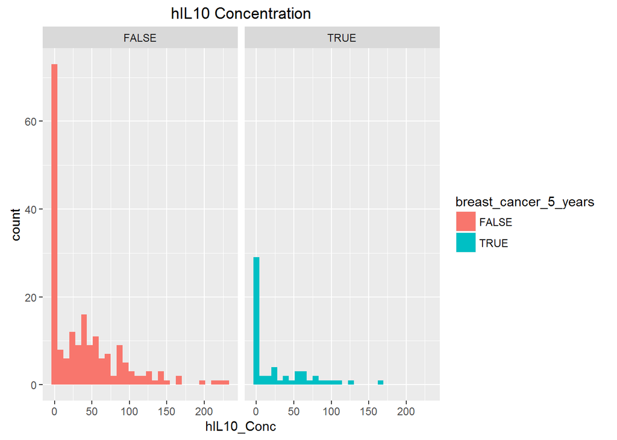

```r
ggplot(dfmydata,aes(x=hIL10_Conc)) +
  geom_histogram(aes(fill=breast_cancer_5_years))+
  facet_wrap(~breast_cancer_5_years)+ggtitle("hIL10 Concentration")
```

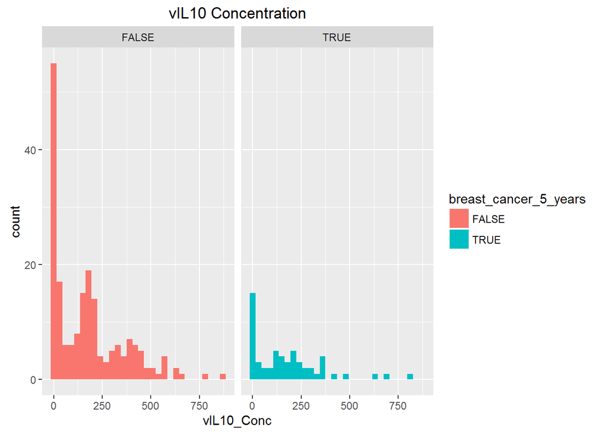

```r
ggplot(dfmydata,aes(x=vIL10_Conc))+
  geom_histogram(aes(fill=breast_cancer_5_years))+
  facet_wrap(~breast_cancer_5_years)+ggtitle("vIL10 Concentration")
```

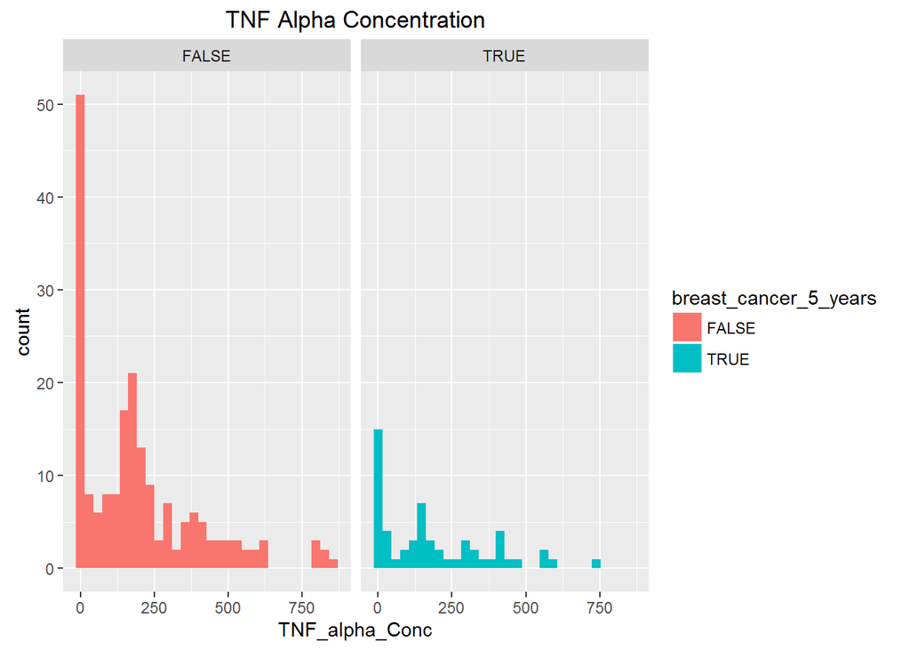

```r
ggplot(dfmydata,aes(x=TNF_alpha_Conc))+
  geom_histogram(aes(fill=breast_cancer_5_years))+
  facet_wrap(~breast_cancer_5_years)+ggtitle("TNF Alpha Concentration")
```

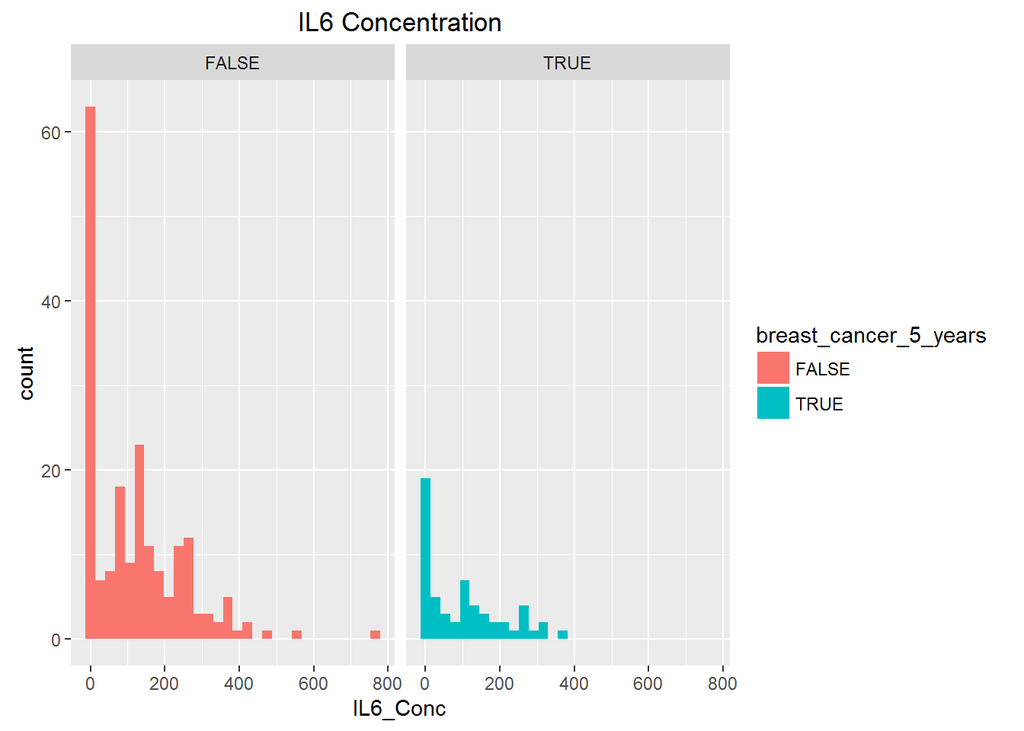

```r
ggplot(dfmydata,aes(x=IL6_Conc))+
  geom_histogram(aes(fill=breast_cancer_5_years))+
  facet_wrap(~breast_cancer_5_years)+ggtitle("IL6 Concentration")
```

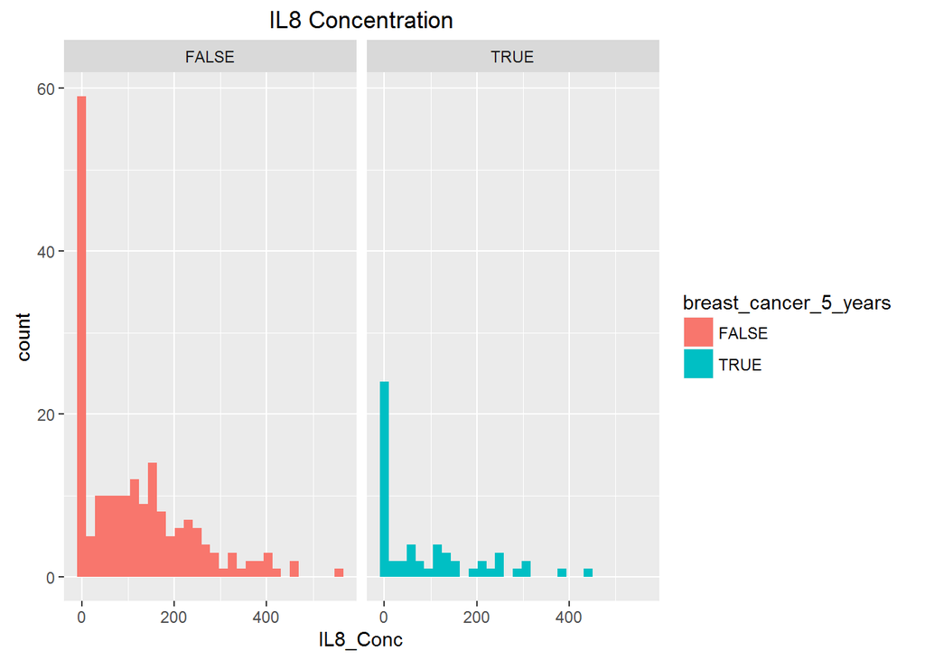

```r
ggplot(dfmydata,aes(x=IL8_Conc))+
  geom_histogram(aes(fill=breast_cancer_5_years))+
  facet_wrap(~breast_cancer_5_years)+ggtitle("IL8 Concentration")
```

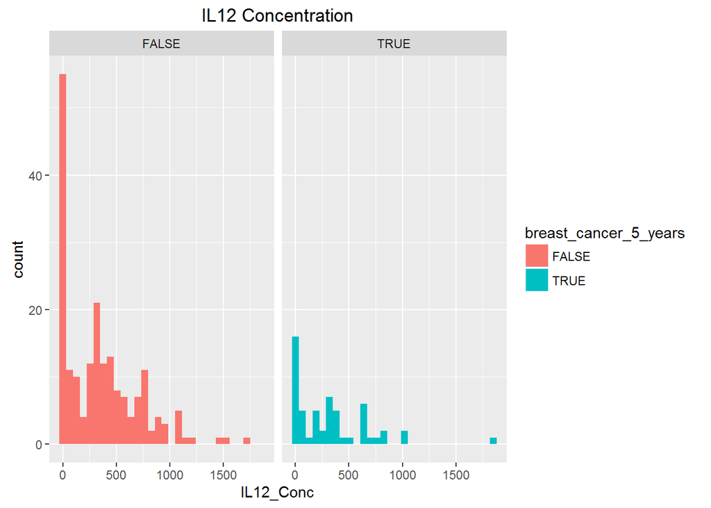

```r
ggplot(dfmydata,aes(x=IL12_Conc))+
  geom_histogram(aes(fill=breast_cancer_5_years))+
  facet_wrap(~breast_cancer_5_years)+ggtitle("IL12 Concentration")
```

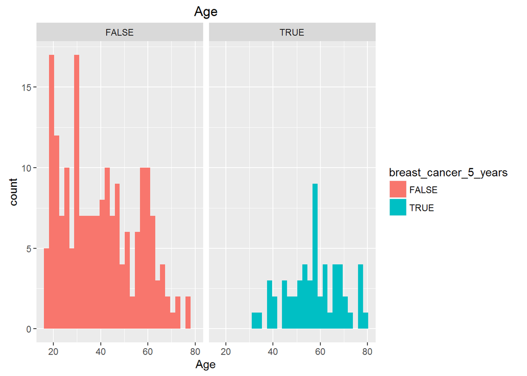

```r
ggplot(dfmydata,aes(x=Age))+
  geom_histogram(aes(fill=breast_cancer_5_years))+
  facet_wrap(~breast_cancer_5_years)+ggtitle("Age")
```

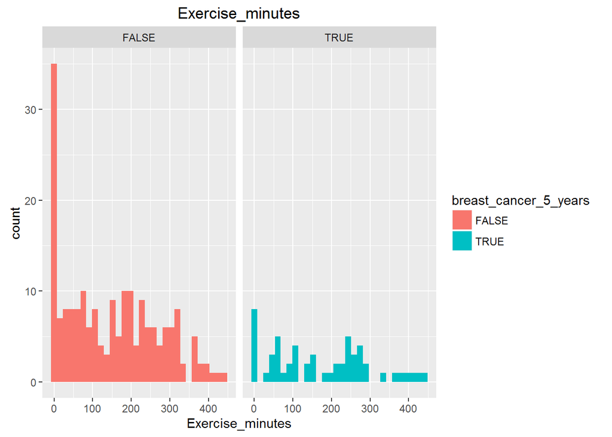

```r
ggplot(dfmydata,aes(x=Exercise_minutes))+
  geom_histogram(aes(fill=breast_cancer_5_years))+
  facet_wrap(~breast_cancer_5_years)+ggtitle("Exercise_minutes")
```

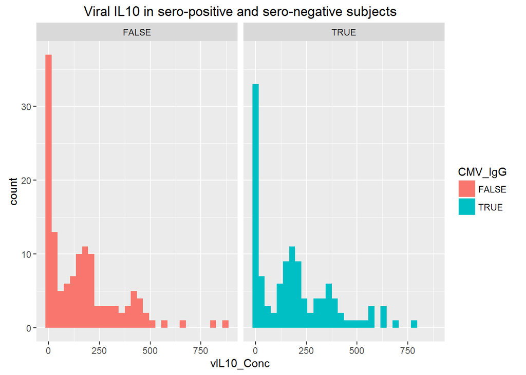

```r
ggplot(dfmydata,aes(x=vIL10_Conc))+
  geom_histogram(aes(fill=CMV_IgG))+
  facet_wrap(~CMV_IgG)+
  ggtitle("Viral IL10 in sero-positive and sero-negative subjects")
```

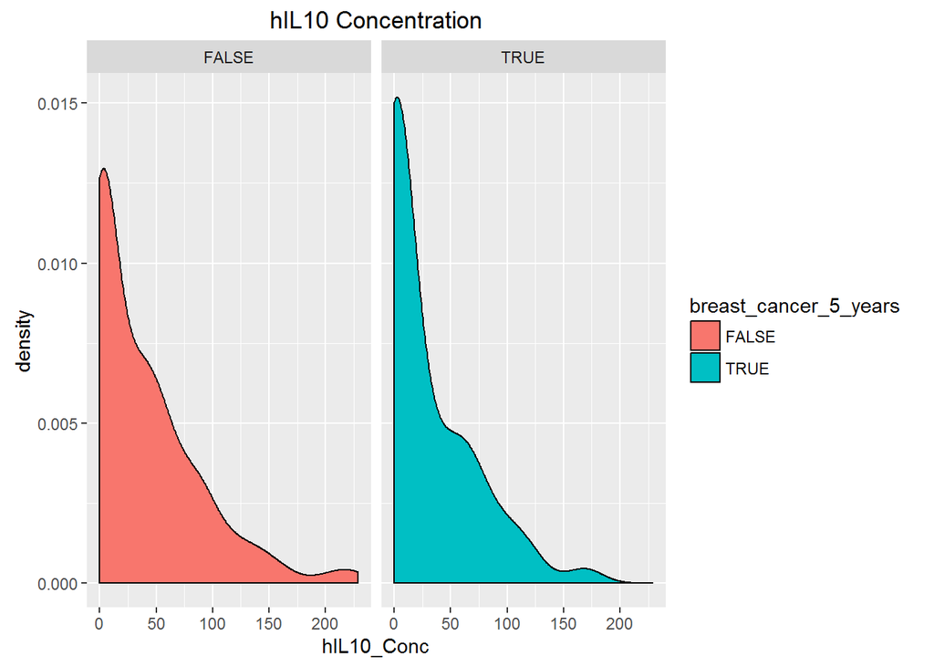

```r
ggplot(dfmydata,aes(x=hIL10_Conc)) +
  geom_density(aes(fill=breast_cancer_5_years))+
  facet_wrap(~breast_cancer_5_years)+ggtitle("hIL10 Concentration")
```

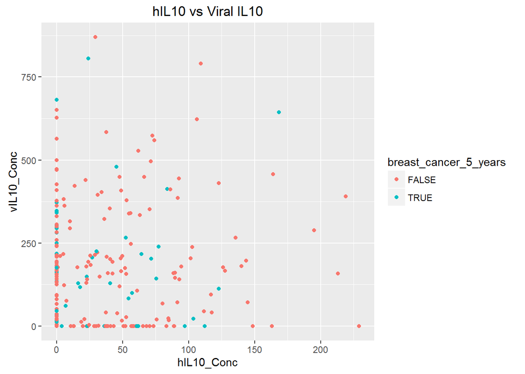

```r
ggplot(dfmydata,aes(x=hIL10_Conc,y=vIL10_Conc)) +
  geom_point(aes(color=breast_cancer_5_years))+
  ggtitle("hIL10 vs Viral IL10")
```

In the above plots it is seen that hIl10 concentration has slightly wider spread in healthy subjecs than in breast cancer subjects. Viral IL10 has generally similar spread in healthy as well as breast cancer subjects ranging from around 0 to 800. But, healthy subset has few higher values which extend till 875.TNF alpha has generally similar spread in healthy as well as breast cancer subsets which extends till 750, but, healthy subset has few values which are greater than 750. Il6 concentration is seen higher in no breast cancer subset than in no breast cancer subset. Il8 concentration has generally similar spread in both the subsets, but, there are few higher values in healthy subset. Il12 concentration is similar both the subsets with few missing values for bins inbetween. It is seen that age has more wider spread in no breast cancer subset ranging from around 18 to 78 whereas age in breast cancer subjects spreads from around 32 to 80. Minutes of exercise per week has generally similar spread in healthy as well as breast cancer subjects. In the scatter plot of hIL10 vs Viral IL10, it is seen that there are higher values in healthy subset than in breast cancer subset.

```r
shapiro.test(breast_cancer$hIL10_Conc)
```

```
##
##  Shapiro-Wilk normality test
##
## data:  breast_cancer$hIL10_Conc
## W = 0.74894, p-value = 1.981e-08
```

```r
shapiro.test(no_breast_cancer$hIL10_Conc)
```

```
##
##  Shapiro-Wilk normality test
##
## data:  no_breast_cancer$hIL10_Conc
## W = 0.80935, p-value = 1.172e-14
```

```r
stand_ctrl.set1 <- no_breast_cancer$hIL10_Conc - median(no_breast_cancer$hIL10_Conc)
stand_case1 <- breast_cancer$hIL10_Conc - median(breast_cancer$hIL10_Conc)
ansari.test(stand_ctrl.set1, stand_case1)
```

```
##
##  Ansari-Bradley test
##
## data:  stand_ctrl.set1 and stand_case1
## AB = 11029, p-value = 1.468e-07
## alternative hypothesis: true ratio of scales is not equal to 1
```

```r
t.test(no_breast_cancer$hIL10_Conc,breast_cancer$hIL10_Conc,var.equal = F)
```

```
##
##  Welch Two Sample t-test
##
## data:  no_breast_cancer$hIL10_Conc and breast_cancer$hIL10_Conc
## t = 1.8734, df = 106, p-value = 0.06376
## alternative hypothesis: true difference in means is not equal to 0
## 95 percent confidence interval:
##  -0.6895424 24.3567688
## sample estimates:
## mean of x mean of y
##  39.68594  27.85233
```

Shapiro test for hIL10 concentration in breast cancer subset shows that it is not normally distrbuted. Shapiro test for hIL10 concentration in no breast cancer subset also shows that it is not normally distrbuted. Ratio of variance of hIL10 concentration in no breast cancer subset and breast cancer subset is not equal to 1. Welch two sample t test performed on hIL10 concentration in breast cancer as well as no breast cancer subsets shows that hIL10 concentration has similar mean in both the subsets. This finding is different from the result of two sample t test on original dataset where difference in mean of hIL concentration in both the subsets was not equal to 0.

```r
shapiro.test(no_breast_cancer$TNF_alpha_Conc)
```

```
##
##  Shapiro-Wilk normality test
##
## data:  no_breast_cancer$TNF_alpha_Conc
## W = 0.86165, p-value = 2.721e-12
```

```r
shapiro.test(breast_cancer$TNF_alpha_Conc)
```

```
##
##  Shapiro-Wilk normality test
##
## data:  breast_cancer$TNF_alpha_Conc
## W = 0.88098, p-value = 5.01e-05
```

```r
stand_ctrl.set2 <- no_breast_cancer$TNF_alpha_Conc - median(no_breast_cancer$TNF_alpha_Conc)

stand_case2 <- breast_cancer$TNF_alpha_Conc - median(breast_cancer$TNF_alpha_Conc)

ansari.test(stand_ctrl.set2,stand_case2)
```

```
##
##  Ansari-Bradley test
##
## data:  stand_ctrl.set2 and stand_case2
## AB = 11941, p-value = 0.2331
## alternative hypothesis: true ratio of scales is not equal to 1
```

```r
t.test(no_breast_cancer$TNF_alpha_Conc, breast_cancer$TNF_alpha_Conc,var.equal = T)
```

```
##
##  Two Sample t-test
##
## data:  no_breast_cancer$TNF_alpha_Conc and breast_cancer$TNF_alpha_Conc
## t = 0.26248, df = 248, p-value = 0.7932
## alternative hypothesis: true difference in means is not equal to 0
## 95 percent confidence interval:
##  -51.01378  66.70103
## sample estimates:
## mean of x mean of y
##  195.6403  187.7967
```

Shapiro test performed on TNF alpha in breast cancer and no breast cancer subsets, showed that they were not normally distributed. Ansari test performed on TNF alpha concentration in breast cancer and no breast cancer subset shows that TNF alpha in both the subsets have equal variance. Two sample t test performed on both the subsets’ TNF alpha concentration shows that difference in mean of TNF alpha in breast cancer and no breast cancer subset is equal to 0. This finding is different from the result of two sample t test on original dataset where difference in mean of TNF alpha concentration in both the subsets was not equal to 0.

```r
shapiro.test(no_breast_cancer$IL12_Conc)
```

```
##
##  Shapiro-Wilk normality test
##
## data:  no_breast_cancer$IL12_Conc
## W = 0.87703, p-value = 1.762e-11
```

```r
shapiro.test(breast_cancer$IL12_Conc)
```

```
##
##  Shapiro-Wilk normality test
##
## data:  breast_cancer$IL12_Conc
## W = 0.81932, p-value = 8.492e-07
```

```r
stand_ctrl.set3 <- no_breast_cancer$IL12_Conc - median(no_breast_cancer$IL12_Conc)
stand_case3 <- breast_cancer$IL12_Conc - median(breast_cancer$IL12_Conc)

ansari.test(stand_ctrl.set3,stand_case3)
```

```
##
##  Ansari-Bradley test
##
## data:  stand_ctrl.set3 and stand_case3
## AB = 11671, p-value = 0.01885
## alternative hypothesis: true ratio of scales is not equal to 1
```

```r
t.test(no_breast_cancer$IL12_Conc, breast_cancer$IL12_Conc,var.equal = F)
```

```
##
##  Welch Two Sample t-test
##
## data:  no_breast_cancer$IL12_Conc and breast_cancer$IL12_Conc
## t = 0.55277, df = 88.342, p-value = 0.5818
## alternative hypothesis: true difference in means is not equal to 0
## 95 percent confidence interval:
##  -77.08341 136.49311
## sample estimates:
## mean of x mean of y
##  348.4623  318.7574
```

Shapiro test performed on IL12 concentration in breast cancer and no breast cancer subsets shows that they are not normally distributed. Ansari test performed on IL12 concentration in both the subsets shows that variance of IL12 in both the subset is not equal. Welch two sample t test shows that the difference in the mean of IL12 concentration in breast cancer and no breast cancer subsets is equal to 0. This finding is different from the result of two sample t test on original dataset where difference in mean of IL12 concentration in both the subsets was not equal to 0.

```r
shapiro.test(no_breast_cancer$IL6_Conc)
```

```
##
##  Shapiro-Wilk normality test
##
## data:  no_breast_cancer$IL6_Conc
## W = 0.85825, p-value = 1.834e-12
```

```r
shapiro.test(breast_cancer$IL6_Conc)
```

```
##
##  Shapiro-Wilk normality test
##
## data:  breast_cancer$IL6_Conc
## W = 0.86086, p-value = 1.192e-05
```

```r
stand_ctrl.set4 <- no_breast_cancer$IL6_Conc - median(no_breast_cancer$IL6_Conc)
stand_case4 <- breast_cancer$IL6_Conc - median(breast_cancer$IL6_Conc)

ansari.test(stand_ctrl.set4,stand_case4)
```

```
##
##  Ansari-Bradley test
##
## data:  stand_ctrl.set4 and stand_case4
## AB = 11575, p-value = 0.005558
## alternative hypothesis: true ratio of scales is not equal to 1
```

```r
t.test(no_breast_cancer$IL6_Conc,breast_cancer$IL6_Conc)
```

```
##
##  Welch Two Sample t-test
##
## data:  no_breast_cancer$IL6_Conc and breast_cancer$IL6_Conc
## t = 1.2887, df = 105.37, p-value = 0.2003
## alternative hypothesis: true difference in means is not equal to 0
## 95 percent confidence interval:
##  -11.65948  54.96325
## sample estimates:
## mean of x mean of y
## 121.39207  99.74019
```

It is seen that IL6 in breast cancer and no breast cancer subsets is not normally distributed. Ansari test performed on IL6 concentration in breast cancer and no breast cancer subsets shows that variance of IL6 concentration in both the subsets is not equal. Welch two sample t test performed on IL6 concentration in breast cancer and no breast cancer subsets shows that IL6 concentration in both the subsets has equal mean. This finding is different from the result of two sample t test on original dataset where difference in mean of IL6 concentration in both the subsets was not equal to 0.

```r
shapiro.test(no_breast_cancer$IL8_Conc)
```

```
##
##  Shapiro-Wilk normality test
##
## data:  no_breast_cancer$IL8_Conc
## W = 0.8735, p-value = 1.132e-11
```

```r
shapiro.test(breast_cancer$IL8_Conc)
```

```
##
##  Shapiro-Wilk normality test
##
## data:  breast_cancer$IL8_Conc
## W = 0.80494, p-value = 3.696e-07
```

```r
stand_ctrl.set5 <- no_breast_cancer$IL8_Conc - median(no_breast_cancer$IL8_Conc)
stand_case5 <- breast_cancer$IL8_Conc - median(breast_cancer$IL8_Conc)

ansari.test(stand_ctrl.set5,stand_case5)
```

```
##
##  Ansari-Bradley test
##
## data:  stand_ctrl.set5 and stand_case5
## AB = 11594, p-value = 0.007113
## alternative hypothesis: true ratio of scales is not equal to 1
```

```r
t.test(no_breast_cancer$IL8_Conc, breast_cancer$IL8_Conc,var.equal = F)
```

```
##
##  Welch Two Sample t-test
##
## data:  no_breast_cancer$IL8_Conc and breast_cancer$IL8_Conc
## t = 1.4357, df = 93.078, p-value = 0.1544
## alternative hypothesis: true difference in means is not equal to 0
## 95 percent confidence interval:
##  -9.559527 59.466233
## sample estimates:
## mean of x mean of y
## 115.79119  90.83784
```

Shapiro test performed on IL8 concentration in breast cancer and no breast cancer subsets show that IL8 concentration is not normally distributed in both the subsets. Ansari test performed on IL8 concentration in both the subsets shows that the variance is not equal in IL8 concnetration in both the subsets. Welch two sample t test performed on IL8 concentration in both the subsets show that mean of IL8 concentration in both the subsets is similar. This finding is different from the result of two sample t test on original dataset where difference in mean of IL8 concentration in both the subsets was not equal to 0.

```r
shapiro.test(no_breast_cancer$vIL10_Conc)
```

```
##
##  Shapiro-Wilk normality test
##
## data:  no_breast_cancer$vIL10_Conc
## W = 0.8652, p-value = 4.135e-12
```

```r
shapiro.test(breast_cancer$vIL10_Conc)
```

```
##
##  Shapiro-Wilk normality test
##
## data:  breast_cancer$vIL10_Conc
## W = 0.85151, p-value = 6.355e-06
```

```r
stand_ctrl.set6 <- no_breast_cancer$vIL10_Conc - median(no_breast_cancer$vIL10_Conc)
stand_case6 <- breast_cancer$vIL10_Conc - median(breast_cancer$vIL10_Conc)

ansari.test(stand_ctrl.set6,stand_case6)
```

```
##
##  Ansari-Bradley test
##
## data:  stand_ctrl.set6 and stand_case6
## AB = 11795, p-value = 0.06905
## alternative hypothesis: true ratio of scales is not equal to 1
```

```r
t.test(no_breast_cancer$vIL10_Conc,breast_cancer$vIL10_Conc, var.equal = T)
```

```
##
##  Two Sample t-test
##
## data:  no_breast_cancer$vIL10_Conc and breast_cancer$vIL10_Conc
## t = -0.10775, df = 248, p-value = 0.9143
## alternative hypothesis: true difference in means is not equal to 0
## 95 percent confidence interval:
##  -56.97599  51.06544
## sample estimates:
## mean of x mean of y
##  172.4738  175.4291
```

It is seen that viral IL10 in breast cancer and no breast cancer subsets is not normally distributed. Ansari test performed on viral IL10 concnetration in breast cancer and no breast cancer subsets shows that ratio of variance of viral IL10 concnetration in both the subsets is equal to 1. Two sample t test performed on viral IL10 concentration in both the subsets shows that viral IL10 concnetration in bothe subsets have similar mean. This finding is same as the original study where viral IL10 concnetration in both the subset have similar mean.

```r
shapiro.test(no_breast_cancer$Age)
```

```
##
##  Shapiro-Wilk normality test
##
## data:  no_breast_cancer$Age
## W = 0.94603, p-value = 1.118e-06
```

```r
shapiro.test(breast_cancer$Age)
```

```
##
##  Shapiro-Wilk normality test
##
## data:  breast_cancer$Age
## W = 0.98184, p-value = 0.5581
```

```r
stand_ctrl.set7 <- no_breast_cancer$Age - median(no_breast_cancer$Age)
stand_case.set7 <- breast_cancer$Age - median(breast_cancer$Age)

ansari.test(stand_ctrl.set7,stand_case.set7)
```

```
##
##  Ansari-Bradley test
##
## data:  stand_ctrl.set7 and stand_case.set7
## AB = 11434, p-value = 0.001007
## alternative hypothesis: true ratio of scales is not equal to 1
```

```r
t.test(no_breast_cancer$Age,breast_cancer$Age,var.equal = F)
```

```
##
##  Welch Two Sample t-test
##
## data:  no_breast_cancer$Age and breast_cancer$Age
## t = -9.2839, df = 119.24, p-value = 9.158e-16
## alternative hypothesis: true difference in means is not equal to 0
## 95 percent confidence interval:
##  -21.32418 -13.82715
## sample estimates:
## mean of x mean of y
##  39.83505  57.41071
```

It is seen that age in no breast cancer subset is not normally distributed. Age in breast cancer subset is normally distributed. Ansari test performed on age in both the subsets shows that age in both the subsets does not have equal variance. Welch two sample t test performed on age in breast cancer and no breast cancer subsets shows that age in both the subsets has different mean. This finding is again same as the original study where age in breast cancer and no breast cancer data-sets has different mean.

```r
fit1 <- glm(dfmydata$breast_cancer_5_years ~ ., data= dfmydata, family = binomial())
summary(fit1)
```

```
##
## Call:
## glm(formula = dfmydata$breast_cancer_5_years ~ ., family = binomial(),
##     data = dfmydata)
##
## Deviance Residuals:
##     Min       1Q   Median       3Q      Max
## -1.8196  -0.6564  -0.3750  -0.1740   2.2854
##
## Coefficients:
##                            Estimate Std. Error z value Pr(>|z|)
## (Intercept)              -5.5537502  1.3352790  -4.159 3.19e-05 ***
## Age                       0.0858580  0.0192030   4.471 7.78e-06 ***
## hIL10_Conc               -0.0039292  0.0041173  -0.954    0.340
## vIL10_Conc                0.0009682  0.0010422   0.929    0.353
## TNF_alpha_Conc            0.0000546  0.0009381   0.058    0.954
## IL6_Conc                  0.0007122  0.0015034   0.474    0.636
## IL8_Conc                 -0.0013366  0.0015928  -0.839    0.401
## IL12_Conc                -0.0001014  0.0005391  -0.188    0.851
## CMV_IgGTRUE              -0.3585914  0.3602569  -0.995    0.320
## Exercise_minutes          0.0018497  0.0015171   1.219    0.223
## smoking_historyTRUE      -0.0558442  0.6168070  -0.091    0.928
## family_breast_cancerTRUE -0.3043670  0.4783007  -0.636    0.525
## menstruation_2015TRUE     0.1516219  0.5036790   0.301    0.763
## ---
## Signif. codes:  0 '***' 0.001 '**' 0.01 '*' 0.05 '.' 0.1 ' ' 1
##
## (Dispersion parameter for binomial family taken to be 1)
##
##     Null deviance: 265.96  on 249  degrees of freedom
## Residual deviance: 205.65  on 237  degrees of freedom
## AIC: 231.65
##
## Number of Fisher Scoring iterations: 5
```

When I tried to predict breast cancer within five years as a function of all the predictor variables, it is seen that only age seem to be the significant varaible with positive fitted coefficient.

```r
fit2 <- glm(dfmydata$breast_cancer_5_years ~ dfmydata$hIL10_Conc + dfmydata$TNF_alpha_Conc + dfmydata$IL6_Conc + dfmydata$IL8_Conc + dfmydata$IL12_Conc, family = binomial())
summary(fit2)
```

```
##
## Call:
## glm(formula = dfmydata$breast_cancer_5_years ~ dfmydata$hIL10_Conc +
##     dfmydata$TNF_alpha_Conc + dfmydata$IL6_Conc + dfmydata$IL8_Conc +
##     dfmydata$IL12_Conc, family = binomial())
##
## Deviance Residuals:
##     Min       1Q   Median       3Q      Max
## -0.9478  -0.7673  -0.6422  -0.4526   2.0419
##
## Coefficients:
##                           Estimate Std. Error z value Pr(>|z|)
## (Intercept)             -5.818e-01  3.355e-01  -1.734   0.0829 .
## dfmydata$hIL10_Conc     -6.592e-03  3.839e-03  -1.717   0.0859 .
## dfmydata$TNF_alpha_Conc  9.952e-05  8.258e-04   0.121   0.9041
## dfmydata$IL6_Conc       -1.318e-03  1.330e-03  -0.991   0.3215
## dfmydata$IL8_Conc       -2.006e-03  1.432e-03  -1.401   0.1612
## dfmydata$IL12_Conc      -3.237e-04  4.521e-04  -0.716   0.4740
## ---
## Signif. codes:  0 '***' 0.001 '**' 0.01 '*' 0.05 '.' 0.1 ' ' 1
##
## (Dispersion parameter for binomial family taken to be 1)
##
##     Null deviance: 265.96  on 249  degrees of freedom
## Residual deviance: 259.06  on 244  degrees of freedom
## AIC: 271.06
##
## Number of Fisher Scoring iterations: 4
```

When breast cancer is modelled as a function of various blood markers, hIL10 concentration is seem to be slightly significant with negative fitted coefficient.

```r
fit3 <- glm(dfmydata$breast_cancer_5_years ~ dfmydata$hIL10_Conc + dfmydata$TNF_alpha_Conc + dfmydata$IL6_Conc + dfmydata$IL8_Conc + dfmydata$IL12_Conc + dfmydata$vIL10_Conc, family = binomial())
summary(fit3)
```

```
##
## Call:
## glm(formula = dfmydata$breast_cancer_5_years ~ dfmydata$hIL10_Conc +
##     dfmydata$TNF_alpha_Conc + dfmydata$IL6_Conc + dfmydata$IL8_Conc +
##     dfmydata$IL12_Conc + dfmydata$vIL10_Conc, family = binomial())
##
## Deviance Residuals:
##     Min       1Q   Median       3Q      Max
## -0.9743  -0.7669  -0.6422  -0.4475   2.0465
##
## Coefficients:
##                           Estimate Std. Error z value Pr(>|z|)
## (Intercept)             -6.142e-01  3.630e-01  -1.692   0.0906 .
## dfmydata$hIL10_Conc     -6.678e-03  3.858e-03  -1.731   0.0835 .
## dfmydata$TNF_alpha_Conc  9.757e-05  8.256e-04   0.118   0.9059
## dfmydata$IL6_Conc       -1.289e-03  1.336e-03  -0.965   0.3345
## dfmydata$IL8_Conc       -2.015e-03  1.432e-03  -1.407   0.1593
## dfmydata$IL12_Conc      -3.301e-04  4.533e-04  -0.728   0.4665
## dfmydata$vIL10_Conc      2.032e-04  8.619e-04   0.236   0.8137
## ---
## Signif. codes:  0 '***' 0.001 '**' 0.01 '*' 0.05 '.' 0.1 ' ' 1
##
## (Dispersion parameter for binomial family taken to be 1)
##
##     Null deviance: 265.96  on 249  degrees of freedom
## Residual deviance: 259.00  on 243  degrees of freedom
## AIC: 273
##
## Number of Fisher Scoring iterations: 4
```

When viral IL10 has been added to the model, still only hIL10 concetration seems to significant.

```r
fit4 <- lm(dfmydata$Age ~ dfmydata$hIL10_Conc + dfmydata$TNF_alpha_Conc + dfmydata$IL6_Conc + dfmydata$IL6_Conc + dfmydata$IL8_Conc + dfmydata$IL12_Conc + dfmydata$vIL10_Conc)
summary(fit4)
```

```
##
## Call:
## lm(formula = dfmydata$Age ~ dfmydata$hIL10_Conc + dfmydata$TNF_alpha_Conc +
##     dfmydata$IL6_Conc + dfmydata$IL6_Conc + dfmydata$IL8_Conc +
##     dfmydata$IL12_Conc + dfmydata$vIL10_Conc)
##
## Residuals:
##     Min      1Q  Median      3Q     Max
## -32.408 -13.036  -0.531  12.325  36.751
##
## Coefficients:
##                          Estimate Std. Error t value Pr(>|t|)
## (Intercept)             52.670229   2.436997  21.613  < 2e-16 ***
## dfmydata$hIL10_Conc     -0.048120   0.021970  -2.190  0.02945 *
## dfmydata$TNF_alpha_Conc -0.001349   0.005253  -0.257  0.79753
## dfmydata$IL6_Conc       -0.023228   0.008408  -2.763  0.00617 **
## dfmydata$IL8_Conc       -0.012855   0.008822  -1.457  0.14640
## dfmydata$IL12_Conc      -0.002999   0.002900  -1.034  0.30199
## dfmydata$vIL10_Conc     -0.009852   0.005676  -1.736  0.08390 .
## ---
## Signif. codes:  0 '***' 0.001 '**' 0.01 '*' 0.05 '.' 0.1 ' ' 1
##
## Residual standard error: 15.98 on 243 degrees of freedom
## Multiple R-squared:  0.07575,    Adjusted R-squared:  0.05293
## F-statistic: 3.319 on 6 and 243 DF,  p-value: 0.003688
```

When age is predicted as a function of blood markers, hIL10 concnetration and IL6 concentration are significant. But, the adjusted R squared of the model is 0.05 which is very low.

```r
fit5 <- glm(dfmydata$breast_cancer_5_years ~ dfmydata$hIL10_Conc, family = binomial())
summary(fit5)
```

```
##
## Call:
## glm(formula = dfmydata$breast_cancer_5_years ~ dfmydata$hIL10_Conc,
##     family = binomial())
##
## Deviance Residuals:
##     Min       1Q   Median       3Q      Max
## -0.7812  -0.7812  -0.6854  -0.5112   2.1057
##
## Coefficients:
##                      Estimate Std. Error z value Pr(>|z|)
## (Intercept)         -1.030604   0.190311  -5.415 6.12e-08 ***
## dfmydata$hIL10_Conc -0.006357   0.003819  -1.664    0.096 .
## ---
## Signif. codes:  0 '***' 0.001 '**' 0.01 '*' 0.05 '.' 0.1 ' ' 1
##
## (Dispersion parameter for binomial family taken to be 1)
##
##     Null deviance: 265.96  on 249  degrees of freedom
## Residual deviance: 262.86  on 248  degrees of freedom
## AIC: 266.86
##
## Number of Fisher Scoring iterations: 4
```

When breast cancer is predicted only as a function of hIL10 concnetration, it is sligtly significant. AIC decreased slightly from the previous logistic regression model.

```r
fit6 <- glm(dfmydata$breast_cancer_5_years ~ dfmydata$Age + dfmydata$Exercise_minutes, family = binomial())
summary(fit6)
```

```
##
## Call:
## glm(formula = dfmydata$breast_cancer_5_years ~ dfmydata$Age +
##     dfmydata$Exercise_minutes, family = binomial())
##
## Deviance Residuals:
##     Min       1Q   Median       3Q      Max
## -1.6831  -0.6432  -0.3687  -0.2069   2.2939
##
## Coefficients:
##                            Estimate Std. Error z value Pr(>|z|)
## (Intercept)               -5.452628   0.764673  -7.131 9.99e-13 ***
## dfmydata$Age               0.080900   0.013077   6.186 6.16e-10 ***
## dfmydata$Exercise_minutes  0.001508   0.001436   1.050    0.294
## ---
## Signif. codes:  0 '***' 0.001 '**' 0.01 '*' 0.05 '.' 0.1 ' ' 1
##
## (Dispersion parameter for binomial family taken to be 1)
##
##     Null deviance: 265.96  on 249  degrees of freedom
## Residual deviance: 210.09  on 247  degrees of freedom
## AIC: 216.09
##
## Number of Fisher Scoring iterations: 5
```

On predicting breast cancer as a function of age and minutes of exercise per week, age is highly significant.

```r
fit7 <- glm(dfmydata$breast_cancer_5_years ~ dfmydata$CMV_IgG,family = binomial())
summary(fit7)
```

```
##
## Call:
## glm(formula = dfmydata$breast_cancer_5_years ~ dfmydata$CMV_IgG,
##     family = binomial())
##
## Deviance Residuals:
##     Min       1Q   Median       3Q      Max
## -0.7452  -0.7452  -0.6744  -0.6744   1.7847
##
## Coefficients:
##                      Estimate Std. Error z value Pr(>|z|)
## (Intercept)           -1.1394     0.2031  -5.610 2.02e-08 ***
## dfmydata$CMV_IgGTRUE  -0.2258     0.3059  -0.738     0.46
## ---
## Signif. codes:  0 '***' 0.001 '**' 0.01 '*' 0.05 '.' 0.1 ' ' 1
##
## (Dispersion parameter for binomial family taken to be 1)
##
##     Null deviance: 265.96  on 249  degrees of freedom
## Residual deviance: 265.41  on 248  degrees of freedom
## AIC: 269.41
##
## Number of Fisher Scoring iterations: 4
```

CMV IgG does not seem to be significant.

```r
fit8 <- glm(dfmydata$breast_cancer_5_years ~ dfmydata$smoking_history + dfmydata$family_breast_cancer, family = binomial())
summary(fit8)
```

```
##
## Call:
## glm(formula = dfmydata$breast_cancer_5_years ~ dfmydata$smoking_history +
##     dfmydata$family_breast_cancer, family = binomial())
##
## Deviance Residuals:
##     Min       1Q   Median       3Q      Max
## -0.9695  -0.7236  -0.7236  -0.5919   1.9121
##
## Coefficients:
##                                   Estimate Std. Error z value Pr(>|z|)
## (Intercept)                        -1.2064     0.1780  -6.777 1.23e-11 ***
## dfmydata$smoking_historyTRUE        0.6956     0.5462   1.273    0.203
## dfmydata$family_breast_cancerTRUE  -0.4465     0.4051  -1.102    0.270
## ---
## Signif. codes:  0 '***' 0.001 '**' 0.01 '*' 0.05 '.' 0.1 ' ' 1
##
## (Dispersion parameter for binomial family taken to be 1)
##
##     Null deviance: 265.96  on 249  degrees of freedom
## Residual deviance: 262.67  on 247  degrees of freedom
## AIC: 268.67
##
## Number of Fisher Scoring iterations: 4
```

Smoking history as well as family history of breast cancer do not seem to be significant.

```r
fit9 <- glm(dfmydata$breast_cancer_5_years ~ dfmydata$menstruation_2015, family = binomial())
summary(fit9)
```

```
##
## Call:
## glm(formula = dfmydata$breast_cancer_5_years ~ dfmydata$menstruation_2015,
##     family = binomial())
##
## Deviance Residuals:
##     Min       1Q   Median       3Q      Max
## -0.9943  -0.4905  -0.4905  -0.4905   2.0868
##
## Coefficients:
##                                Estimate Std. Error z value Pr(>|z|)
## (Intercept)                     -0.4473     0.2050  -2.182   0.0291 *
## dfmydata$menstruation_2015TRUE  -1.6098     0.3292  -4.890 1.01e-06 ***
## ---
## Signif. codes:  0 '***' 0.001 '**' 0.01 '*' 0.05 '.' 0.1 ' ' 1
##
## (Dispersion parameter for binomial family taken to be 1)
##
##     Null deviance: 265.96  on 249  degrees of freedom
## Residual deviance: 239.78  on 248  degrees of freedom
## AIC: 243.78
##
## Number of Fisher Scoring iterations: 4
```

History of menstruation in 2015 is highly significant and has negative coefficient which also means that history of menstruation reduces the log odd of breast cancer. It can also be said that breast cancer is more prevalent in menopausal group.

```r
fit10 <- glm(dfmydata$breast_cancer_5_years ~ dfmydata$Age + dfmydata$menstruation_2015, family = binomial())
summary(fit10)
```

```
##
## Call:
## glm(formula = dfmydata$breast_cancer_5_years ~ dfmydata$Age +
##     dfmydata$menstruation_2015, family = binomial())
##
## Deviance Residuals:
##     Min       1Q   Median       3Q      Max
## -1.6489  -0.6655  -0.3614  -0.2102   2.3152
##
## Coefficients:
##                                Estimate Std. Error z value Pr(>|z|)
## (Intercept)                    -5.61465    1.14479  -4.905 9.36e-07 ***
## dfmydata$Age                    0.08672    0.01846   4.697 2.64e-06 ***
## dfmydata$menstruation_2015TRUE  0.23077    0.49293   0.468     0.64
## ---
## Signif. codes:  0 '***' 0.001 '**' 0.01 '*' 0.05 '.' 0.1 ' ' 1
##
## (Dispersion parameter for binomial family taken to be 1)
##
##     Null deviance: 265.96  on 249  degrees of freedom
## Residual deviance: 210.98  on 247  degrees of freedom
## AIC: 216.98
##
## Number of Fisher Scoring iterations: 5
```

Here, age seem to be a highly significant variable, but, history of menstruation in 2015 is no longer a siginficant variable.

```r
fit11 <- glm(dfmydata$breast_cancer_5_years ~ dfmydata$family_breast_cancer, family = binomial())
summary(fit11)
```

```
##
## Call:
## glm(formula = dfmydata$breast_cancer_5_years ~ dfmydata$family_breast_cancer,
##     family = binomial())
##
## Deviance Residuals:
##     Min       1Q   Median       3Q      Max
## -0.7449  -0.7449  -0.7449  -0.5919   1.9121
##
## Coefficients:
##                                   Estimate Std. Error z value Pr(>|z|)
## (Intercept)                        -1.1403     0.1676  -6.805 1.01e-11 ***
## dfmydata$family_breast_cancerTRUE  -0.5126     0.4006  -1.280    0.201
## ---
## Signif. codes:  0 '***' 0.001 '**' 0.01 '*' 0.05 '.' 0.1 ' ' 1
##
## (Dispersion parameter for binomial family taken to be 1)
##
##     Null deviance: 265.96  on 249  degrees of freedom
## Residual deviance: 264.20  on 248  degrees of freedom
## AIC: 268.2
##
## Number of Fisher Scoring iterations: 4
```

Here, family history of breast cancer doesnot seem to be significant.

### Conclusion

In the original study, it is seen that concentration of blood markers is higher in healthy subjects than in breast cancer subjects. However, here, it is seen that the blood markers are more or less same in healthy as well as breast cancer subjects. Viral IL10 concnetration in the original study is same in healthy as well as breast cancer subjects. Here, also we see that it is more or less same in both the groups. The spread of age and minutes of exercise per week is also same as original study. Two sample t-test performed on all the blood markers has the output which is different from the original study. Viral IL10 and age has similar result of two sample t-test as the original study. When breast cancer is modelled as a function of various variables, age is seen to be significant in predicting breast cancer. This result is also obtained in the original study. When modelling breast cancer as a function of blood markers, hIL10 concentration is slightly significant. In the original study, no blood markers are siginificant in predicting breast cancer. Minutes of exercise per week is positively corelated and significant when breast cancer is predicted as a function of it in the original study which contradicts with the domain knowledge. Here, minutes of exercise is not siginificant when breast cancer is modelled as a function of age and exercise minutes. CMV IgG, smoking history and family history are not significant in predicting breast cancer here. This again matches with the output obtained from the original study. History of menstruation in 2015 is significant when predicting breast cancer as a function of this single variable. But, when age is added to the model, the menstruation history is no longer seen to be significant. In the original study, menstruation history in 2015 is highly significant with negative fitted coefficient. These diference in corelation of various variables with breast cancer can be either due to difference in the correlation among variables, for example, correlation of variables with age, or due to limited number of variables that are being simulated here and hence, the relation among various variables might not be captured. The original study has 175 predictor variables.